# Flight_price

```python
#import libraries
import pandas as pd
import matplotlib.pyplot as plt
import numpy as np
import statsmodels.api as sm
import seaborn as sns
from sklearn.model_selection import train_test_split
from sklearn.linear_model import LinearRegression
from sklearn.preprocessing import StandardScaler
```

```python
df = pd.read_csv("/Users/macbook/Downloads/ProjectPro/Path1 Pro 1 Linear Regression Model Project/exercise/Flight_Price_Prediction.csv")
df.head(5)
```

|  | Unnamed: 0 | airline | flight | source_city | departure_time | stops | arrival_time | destination_city | class | duration | days_left | price |
| --- | --- | --- | --- | --- | --- | --- | --- | --- | --- | --- | --- | --- |
| 0 | 0 | SpiceJet | SG-8709 | Delhi | Evening | zero | Night | Mumbai | Economy | 2.17 | 1 | 5953 |
| 1 | 1 | SpiceJet | SG-8157 | Delhi | Early_Morning | zero | Morning | Mumbai | Economy | 2.33 | 1 | 5953 |
| 2 | 2 | AirAsia | I5-764 | Delhi | Early_Morning | zero | Early_Morning | Mumbai | Economy | 2.17 | 1 | 5956 |
| 3 | 3 | Vistara | UK-995 | Delhi | Morning | zero | Afternoon | Mumbai | Economy | 2.25 | 1 | 5955 |
| 4 | 4 | Vistara | UK-963 | Delhi | Morning | zero | Morning | Mumbai | Economy | 2.33 | 1 | 5955 |

**Hypothesis EDA:** Q1: Does the price vary with Airlines for the same source_city to destination_city?

```python
df['source_city'].unique()
```

```
array(['Delhi', 'Mumbai', 'Bangalore', 'Kolkata', 'Hyderabad', 'Chennai'],
      dtype=object)
```

```python
df['destination_city'].unique()
```

```
array(['Mumbai', 'Bangalore', 'Kolkata', 'Hyderabad', 'Chennai', 'Delhi'],
      dtype=object)
```

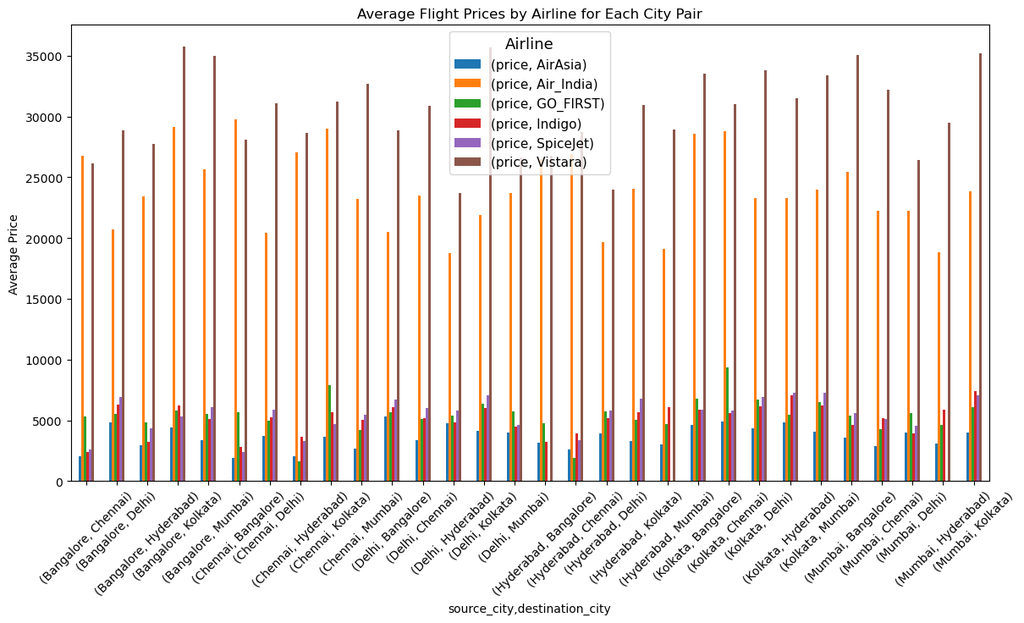

```python
grouped = df.groupby(['source_city', 'destination_city', 'airline']).agg({'price': 'mean'}).unstack()
grouped.plot(kind='bar', figsize=(14, 7), ylabel='Average Price', title='Average Flight Prices by Airline for Each City Pair')
plt.xticks(rotation=45)
plt.legend(title='Airline', title_fontsize='13', fontsize='11')
plt.show()
```

```python
print(grouped.head())
```

```
                                    price                             \
airline                           AirAsia     Air_India     GO_FIRST
source_city destination_city
Bangalore   Chennai           2073.043478  26765.567702  5351.945799
            Delhi             4807.092426  20699.099886  5524.702628
            Hyderabad         2931.494792  23395.956912  4828.217759
            Kolkata           4443.468160  29105.826259  5794.162658
            Mumbai            3342.385350  25625.530802  5533.795064


airline                            Indigo     SpiceJet       Vistara
source_city destination_city
Bangalore   Chennai           2363.326241  2613.310345  26137.494814
            Delhi             6273.496685  6901.620408  28848.974553
            Hyderabad         3220.662367  4338.000000  27775.226846
            Kolkata           6230.334759  5297.967153  35746.714874
            Mumbai            5112.265675  6058.643312  34961.383271
```

Q2: How is the price affected when tickets are bought just 1 or 2 days before departure?

```
No artists with labels found to put in legend.  Note that artists whose label start with an underscore are ignored when legend() is called with no argument.
```

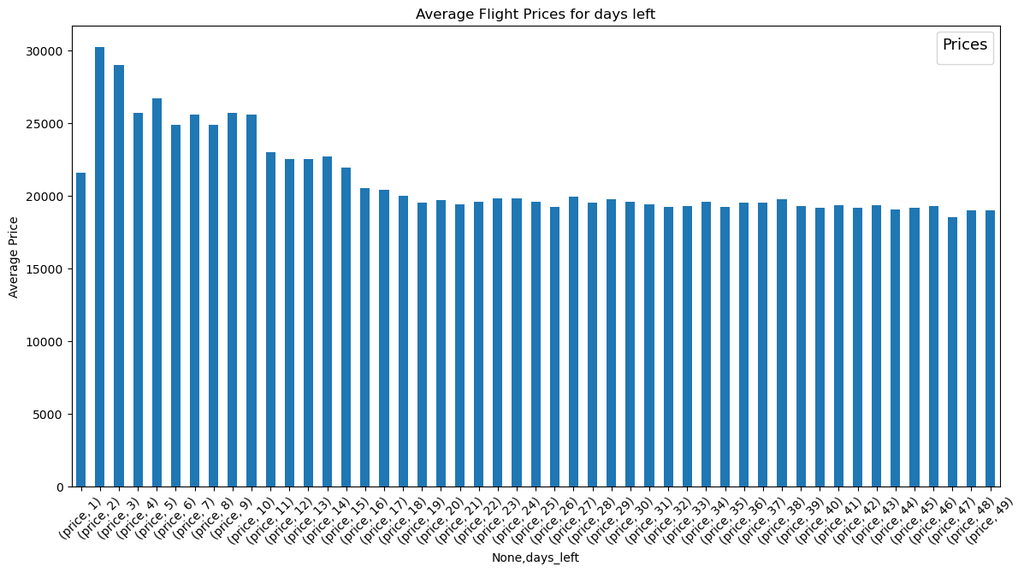

```python
grouped = df.groupby(['days_left']).agg({'price': 'mean'}).unstack()
grouped.plot(kind='bar', figsize=(14, 7), ylabel='Average Price', title='Average Flight Prices for days left')
plt.xticks(rotation=45)
plt.legend(title='Prices', title_fontsize='13', fontsize='11')
plt.show()
```

Q3:Does the ticket price change based on the departure time and arrival time?

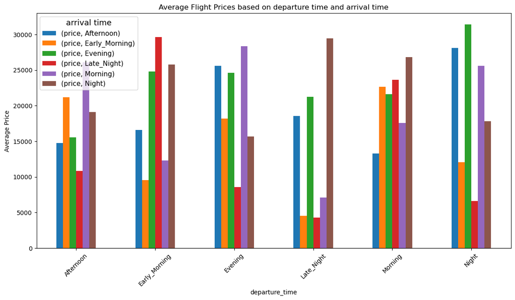

```python
grouped = df.groupby(['departure_time', 'arrival_time']).agg({'price': 'mean'}).unstack()
grouped.plot(kind='bar', figsize=(14, 7), ylabel='Average Price', title='Average Flight Prices based on departure time and arrival time')
plt.xticks(rotation=45)
plt.legend(title='arrival time', title_fontsize='13', fontsize='11')
plt.show()
```

Q4:Check the distribution of the Price variable and remove outliers to create a new dataset.

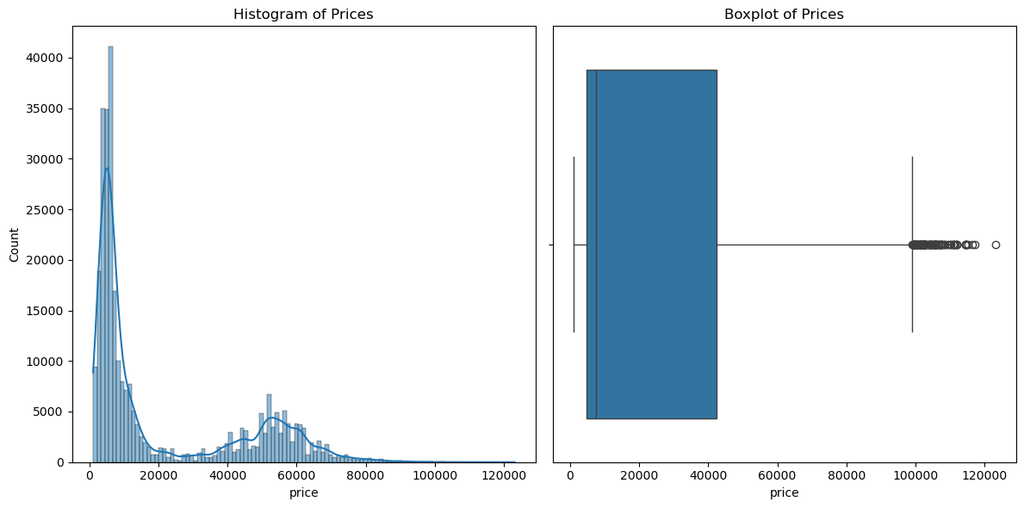

```python
# Assuming 'df' is already loaded with the data
# Step 1: Visualize the Distribution
plt.figure(figsize=(12, 6))

# Histogram
plt.subplot(1, 2, 1)
sns.histplot(df['price'], kde=True)
plt.title('Histogram of Prices')

# Boxplot
plt.subplot(1, 2, 2)
sns.boxplot(x=df['price'])
plt.title('Boxplot of Prices')

plt.tight_layout()
plt.show()
```

Step 2: Removing Outliers To remove outliers using the Interquartile Range (IQR) method, you can use the following code snippet:

```python
# Calculate Q1, Q3, and IQR
Q1 = df['price'].quantile(0.25)
Q3 = df['price'].quantile(0.75)
IQR = Q3 - Q1

# Define bounds for outliers
lower_bound = Q1 - 1.5 * IQR
upper_bound = Q3 + 1.5 * IQR

# Remove outliers
df_clean = df[(df['price'] >= lower_bound) & (df['price'] <= upper_bound)]
```

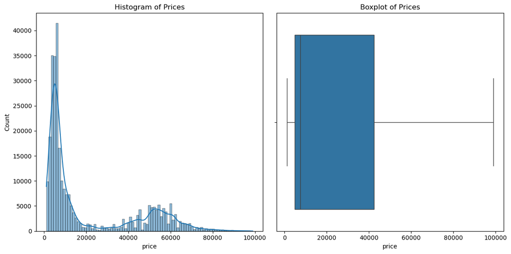

```python
plt.figure(figsize=(12, 6))

# Histogram
plt.subplot(1, 2, 1)
sns.histplot(df_clean['price'], kde=True)
plt.title('Histogram of Prices')

# Boxplot
plt.subplot(1, 2, 2)
sns.boxplot(x=df_clean['price'])
plt.title('Boxplot of Prices')

plt.tight_layout()
plt.show()
```

Q5: Build a Linear regression Model with all the features (m1), select only the top 5 features using the model coefficient, and rebuild the regression model (m2) again using Statsmodels. Observe if there are any differences between the two models in Adjusted-R2 and R2.

```python
# Step 1
# Convert categorical variables using one-hot encoding
df_encoded = pd.get_dummies(df, columns=['airline', 'source_city', 'departure_time', 'arrival_time', 'destination_city', 'class', 'stops'])

# Optionally scale the numeric features
scaler = StandardScaler()
df_encoded[['duration', 'days_left']] = scaler.fit_transform(df_encoded[['duration', 'days_left']])
```

```python
df_encoded.head(5)
```

|  | Unnamed: 0 | flight | duration | days_left | price | airline_AirAsia | airline_Air_India | airline_GO_FIRST | airline_Indigo | airline_SpiceJet | ... | destination_city_Chennai | destination_city_Delhi | destination_city_Hyderabad | destination_city_Kolkata | destination_city_Mumbai | class_Business | class_Economy | stops_one | stops_two_or_more | stops_zero |
| --- | --- | --- | --- | --- | --- | --- | --- | --- | --- | --- | --- | --- | --- | --- | --- | --- | --- | --- | --- | --- | --- |
| 0 | 0 | SG-8709 | -1.397531 | -1.843875 | 5953 | False | False | False | False | True | ... | False | False | False | False | True | False | True | False | False | True |
| 1 | 1 | SG-8157 | -1.375284 | -1.843875 | 5953 | False | False | False | False | True | ... | False | False | False | False | True | False | True | False | False | True |
| 2 | 2 | I5-764 | -1.397531 | -1.843875 | 5956 | True | False | False | False | False | ... | False | False | False | False | True | False | True | False | False | True |
| 3 | 3 | UK-995 | -1.386407 | -1.843875 | 5955 | False | False | False | False | False | ... | False | False | False | False | True | False | True | False | False | True |
| 4 | 4 | UK-963 | -1.375284 | -1.843875 | 5955 | False | False | False | False | False | ... | False | False | False | False | True | False | True | False | False | True |

5 rows × 40 columns

```python
# Splitting the data
X = df_encoded.drop(['price','flight','Unnamed: 0'], axis=1)  # all features except the target
y = df_encoded['price']              # target variable
X_train, X_test, y_train, y_test = train_test_split(X, y, test_size=0.2, random_state=42)

# Model 1: Linear Regression with all features
lr = LinearRegression()
results=lr.fit(X_train, y_train)
print("All Features Model R-squared:", lr.score(X_test, y_test))
#print(results.summary())
```

```
All Features Model R-squared: 0.9113048118977971
```

```python
# Selecting top 5 features based on coefficients
coefficients = pd.DataFrame(lr.coef_, X.columns, columns=['Coefficient'])
top_features = coefficients.abs().sort_values(by='Coefficient', ascending=False).head(5).index
print(top_features)
```

```
Index(['stops_two_or_more', 'stops_one', 'stops_zero', 'class_Business',
       'class_Economy'],
      dtype='object')
```

```python
print(X_train.info())
print(X_train.isnull().sum())  # Check for missing values
```

```
<class 'pandas.core.frame.DataFrame'>
Index: 240122 entries, 148417 to 121958
Data columns (total 37 columns):
 #   Column                        Non-Null Count   Dtype
---  ------                        --------------   -----
 0   duration                      240122 non-null  float64
 1   days_left                     240122 non-null  float64
 2   airline_AirAsia               240122 non-null  bool
 3   airline_Air_India             240122 non-null  bool
 4   airline_GO_FIRST              240122 non-null  bool
 5   airline_Indigo                240122 non-null  bool
 6   airline_SpiceJet              240122 non-null  bool
 7   airline_Vistara               240122 non-null  bool
 8   source_city_Bangalore         240122 non-null  bool
 9   source_city_Chennai           240122 non-null  bool
 10  source_city_Delhi             240122 non-null  bool
 11  source_city_Hyderabad         240122 non-null  bool
 12  source_city_Kolkata           240122 non-null  bool
 13  source_city_Mumbai            240122 non-null  bool
 14  departure_time_Afternoon      240122 non-null  bool
 15  departure_time_Early_Morning  240122 non-null  bool
 16  departure_time_Evening        240122 non-null  bool
 17  departure_time_Late_Night     240122 non-null  bool
 18  departure_time_Morning        240122 non-null  bool
 19  departure_time_Night          240122 non-null  bool
 20  arrival_time_Afternoon        240122 non-null  bool
 21  arrival_time_Early_Morning    240122 non-null  bool
 22  arrival_time_Evening          240122 non-null  bool
 23  arrival_time_Late_Night       240122 non-null  bool
 24  arrival_time_Morning          240122 non-null  bool
 25  arrival_time_Night            240122 non-null  bool
 26  destination_city_Bangalore    240122 non-null  bool
 27  destination_city_Chennai      240122 non-null  bool
 28  destination_city_Delhi        240122 non-null  bool
 29  destination_city_Hyderabad    240122 non-null  bool
 30  destination_city_Kolkata      240122 non-null  bool
 31  destination_city_Mumbai       240122 non-null  bool
 32  class_Business                240122 non-null  bool
 33  class_Economy                 240122 non-null  bool
 34  stops_one                     240122 non-null  bool
```

[output cut: 28 more lines]

```
arrival_time_Late_Night         0
arrival_time_Morning            0
arrival_time_Night              0
destination_city_Bangalore      0
destination_city_Chennai        0
destination_city_Delhi          0
destination_city_Hyderabad      0
destination_city_Kolkata        0
destination_city_Mumbai         0
class_Business                  0
class_Economy                   0
stops_one                       0
stops_two_or_more               0
stops_zero                      0
dtype: int64
```

```python
# Convert data types if necessary, example for converting all columns to float
X_train = X_train.astype(float)
X_test = X_test.astype(float)
```

```python
# Model 2: Linear Regression with top 5 features
X_train_top = X_train[top_features]
X_test_top = X_test[top_features]
X_train_top = sm.add_constant(X_train_top)  # adding a constant for statsmodels
model = sm.OLS(y_train, X_train_top)
results = model.fit()
print("Top 5 Features Model Summary:\n", results.summary())
```

```
Top 5 Features Model Summary:
                             OLS Regression Results
==============================================================================
Dep. Variable:                  price   R-squared:                       0.895
Model:                            OLS   Adj. R-squared:                  0.895
Method:                 Least Squares   F-statistic:                 5.140e+05
Date:                Fri, 24 May 2024   Prob (F-statistic):               0.00
Time:                        20:59:30   Log-Likelihood:            -2.4781e+06
No. Observations:              240122   AIC:                         4.956e+06
Df Residuals:                  240117   BIC:                         4.956e+06
Df Model:                           4
Covariance Type:            nonrobust
=====================================================================================
                        coef    std err          t      P>|t|      [0.025      0.975]
-------------------------------------------------------------------------------------
const              1.243e+15   2.34e+15      0.532      0.595   -3.34e+15    5.82e+15
stops_two_or_more  7.526e+15   3.21e+15      2.348      0.019    1.24e+15    1.38e+16
stops_one          7.526e+15   3.21e+15      2.348      0.019    1.24e+15    1.38e+16
stops_zero         7.526e+15   3.21e+15      2.348      0.019    1.24e+15    1.38e+16
class_Business    -8.769e+15   3.87e+15     -2.267      0.023   -1.63e+16   -1.19e+15
class_Economy     -8.769e+15   3.87e+15     -2.267      0.023   -1.63e+16   -1.19e+15
==============================================================================
Omnibus:                    35619.446   Durbin-Watson:                   1.998
Prob(Omnibus):                  0.000   Jarque-Bera (JB):           241118.542
Skew:                           0.538   Prob(JB):                         0.00
Kurtosis:                       7.790   Cond. No.                     7.56e+14
==============================================================================

Notes:
[1] Standard Errors assume that the covariance matrix of the errors is correctly specified.
[2] The smallest eigenvalue is 9.79e-25. This might indicate that there are
strong multicollinearity problems or that the design matrix is singular.
```

Q6: Build a Linear Regression model using Scikit learn and Statsmodels; compare the results Analyze the impact of airlines, time of purchase, and departure/arrival time on ticket prices.

```python
df_encoded.info()
```

```
<class 'pandas.core.frame.DataFrame'>
RangeIndex: 300153 entries, 0 to 300152
Data columns (total 40 columns):
 #   Column                        Non-Null Count   Dtype
---  ------                        --------------   -----
 0   Unnamed: 0                    300153 non-null  int64
 1   flight                        300153 non-null  object
 2   duration                      300153 non-null  float64
 3   days_left                     300153 non-null  float64
 4   price                         300153 non-null  int64
 5   airline_AirAsia               300153 non-null  bool
 6   airline_Air_India             300153 non-null  bool
 7   airline_GO_FIRST              300153 non-null  bool
 8   airline_Indigo                300153 non-null  bool
 9   airline_SpiceJet              300153 non-null  bool
```

[output cut: 32 more lines]

```python
# Splitting the data
X = df_encoded[['airline_AirAsia', 'airline_Air_India', 'airline_GO_FIRST','airline_Indigo', 'airline_SpiceJet', 'airline_Vistara','departure_time_Afternoon', 'departure_time_Early_Morning',
       'departure_time_Evening', 'departure_time_Late_Night',
       'departure_time_Morning', 'departure_time_Night',
       'arrival_time_Afternoon', 'arrival_time_Early_Morning',
       'arrival_time_Evening', 'arrival_time_Late_Night',
       'arrival_time_Morning', 'arrival_time_Night','days_left']]  # all features except the target
y = df_encoded['price']              # target variable
X_train, X_test, y_train, y_test = train_test_split(X, y, test_size=0.2, random_state=42)
```

```python
# Convert data types if necessary, example for converting all columns to float
X_train = X_train.astype(float)
X_test = X_test.astype(float)
```

```python
# Build the Scikit-learn model
model_sklearn = LinearRegression()
model_sklearn.fit(X_train, y_train)
print("Scikit-learn R-squared:", model_sklearn.score(X_test, y_test))

# Build the Statsmodels model
X_train_sm = sm.add_constant(X_train)  # Adding a constant for Statsmodels
model_sm = sm.OLS(y_train, X_train_sm)
results_sm = model_sm.fit()
print("Statsmodels Summary:")
print(results_sm.summary())
```

```
Scikit-learn R-squared: 0.2321136903172828
Statsmodels Summary:
                            OLS Regression Results
==============================================================================
Dep. Variable:                  price   R-squared:                       0.230
Model:                            OLS   Adj. R-squared:                  0.230
Method:                 Least Squares   F-statistic:                     4484.
Date:                Fri, 24 May 2024   Prob (F-statistic):               0.00
Time:                        21:45:00   Log-Likelihood:            -2.7177e+06
No. Observations:              240122   AIC:                         5.436e+06
Df Residuals:                  240105   BIC:                         5.436e+06
Df Model:                          16
Covariance Type:            nonrobust
================================================================================================
                                   coef    std err          t      P>|t|      [0.025      0.975]
------------------------------------------------------------------------------------------------
const                         8326.8150     79.310    104.991      0.000    8171.369    8482.261
airline_AirAsia              -6841.8486    159.031    -43.022      0.000   -7153.546   -6530.151
airline_Air_India             1.228e+04     87.107    140.995      0.000    1.21e+04    1.25e+04
airline_GO_FIRST             -5205.5496    134.771    -38.625      0.000   -5469.698   -4941.402
airline_Indigo               -5763.3065    105.499    -54.629      0.000   -5970.083   -5556.530
airline_SpiceJet             -5163.0744    204.670    -25.226      0.000   -5564.222   -4761.927
airline_Vistara               1.902e+04     78.792    241.382      0.000    1.89e+04    1.92e+04
departure_time_Afternoon       556.1055    131.655      4.224      0.000     298.064     814.147
departure_time_Early_Morning   993.1766    122.932      8.079      0.000     752.233    1234.120
departure_time_Evening        1353.9794    122.593     11.044      0.000    1113.700    1594.259
departure_time_Late_Night     2356.8935    535.251      4.403      0.000    1307.816    3405.971
departure_time_Morning         840.3128    122.590      6.855      0.000     600.039    1080.587
departure_time_Night          2226.3471    130.897     17.008      0.000    1969.793    2482.901
arrival_time_Afternoon         851.8369    109.792      7.759      0.000     636.647    1067.027
arrival_time_Early_Morning    -346.0515    158.777     -2.179      0.029    -657.250     -34.853
arrival_time_Evening          2597.8695     86.407     30.065      0.000    2428.514    2767.225
arrival_time_Late_Night       2041.8276    171.195     11.927      0.000    1706.289    2377.366
arrival_time_Morning          1091.6528     91.450     11.937      0.000     912.413    1270.893
arrival_time_Night            2089.6797     81.533     25.630      0.000    1929.877    2249.482
days_left                    -1803.1169     40.695    -44.308      0.000   -1882.878   -1723.356
==============================================================================
Omnibus:                    20943.172   Durbin-Watson:                   2.002
Prob(Omnibus):                  0.000   Jarque-Bera (JB):            16737.193
Skew:                           0.559   Prob(JB):                         0.00
Kurtosis:                       2.349   Cond. No.                     4.44e+15
==============================================================================

Notes:
[1] Standard Errors assume that the covariance matrix of the errors is correctly specified.
[2] The smallest eigenvalue is 2.11e-26. This might indicate that there are
strong multicollinearity problems or that the design matrix is singular.
```